# Optimal Treatment Analysis

## Outcome Variable

**Outcome Variable:** whz

## Predictor Variables

**Intervention Variable:** impsan

**Adjustment Set:**

- arm
- sex
- W_mage
- meducyrs
- feducyrs
- hhwealth_quart
- hfoodsec
- W_mhtcm
- W_mwtkg
- W_mbmi
- W_nrooms
- W_nchldlt5
- W_parity
- impfloor
- safeh20
- delta_W_mage
- delta_meducyrs
- delta_feducyrs
- delta_hhwealth_quart
- delta_hfoodsec
- delta_W_mhtcm
- delta_W_mwtkg
- delta_W_mbmi
- delta_W_nrooms
- delta_W_nchldlt5
- delta_W_parity
- delta_impfloor
- delta_safeh20

## Stratifying Variables

The analysis was stratified on these variable(s):

- agecat
- studyid
- country

## Data Summary

| agecat | studyid | country | impsan | n_cell | n |
| --- | --- | --- | --- | --- | --- |
| Birth | ki0047075b-MAL-ED | BANGLADESH | 1 | 168 | 201 |
| Birth | ki0047075b-MAL-ED | BANGLADESH | 0 | 33 | 201 |
| Birth | ki0047075b-MAL-ED | BRAZIL | 1 | 56 | 57 |
| Birth | ki0047075b-MAL-ED | BRAZIL | 0 | 1 | 57 |
| Birth | ki0047075b-MAL-ED | INDIA | 1 | 14 | 39 |
| Birth | ki0047075b-MAL-ED | INDIA | 0 | 25 | 39 |
| Birth | ki0047075b-MAL-ED | NEPAL | 1 | 24 | 25 |
| Birth | ki0047075b-MAL-ED | NEPAL | 0 | 1 | 25 |
| Birth | ki0047075b-MAL-ED | PERU | 1 | 50 | 203 |
| Birth | ki0047075b-MAL-ED | PERU | 0 | 153 | 203 |
| Birth | ki0047075b-MAL-ED | SOUTH AFRICA | 1 | 0 | 94 |
| Birth | ki0047075b-MAL-ED | SOUTH AFRICA | 0 | 94 | 94 |
| Birth | ki0047075b-MAL-ED | TANZANIA, UNITED REPUBLIC OF | 1 | 0 | 110 |
| Birth | ki0047075b-MAL-ED | TANZANIA, UNITED REPUBLIC OF | 0 | 110 | 110 |
| Birth | ki1017093-NIH-Birth | BANGLADESH | 1 | 222 | 575 |
| Birth | ki1017093-NIH-Birth | BANGLADESH | 0 | 353 | 575 |
| Birth | ki1017093b-PROVIDE | BANGLADESH | 1 | 43 | 45 |
| Birth | ki1017093b-PROVIDE | BANGLADESH | 0 | 2 | 45 |
| Birth | ki1017093c-NIH-Crypto | BANGLADESH | 1 | 610 | 696 |
| Birth | ki1017093c-NIH-Crypto | BANGLADESH | 0 | 86 | 696 |
| Birth | ki1114097-CONTENT | PERU | 1 | 1 | 2 |
| Birth | ki1114097-CONTENT | PERU | 0 | 1 | 2 |
| Birth | ki1135781-COHORTS | GUATEMALA | 1 | 43 | 449 |
| Birth | ki1135781-COHORTS | GUATEMALA | 0 | 406 | 449 |
| Birth | ki1135781-COHORTS | INDIA | 1 | 1685 | 4461 |
| Birth | ki1135781-COHORTS | INDIA | 0 | 2776 | 4461 |
| Birth | ki1135781-COHORTS | PHILIPPINES | 1 | 177 | 1126 |
| Birth | ki1135781-COHORTS | PHILIPPINES | 0 | 949 | 1126 |
| Birth | kiGH5241-JiVitA-3 | BANGLADESH | 1 | 15611 | 22057 |
| Birth | kiGH5241-JiVitA-3 | BANGLADESH | 0 | 6446 | 22057 |

[output cut: 70 more lines]

The following strata were considered:

- agecat: 24 months, studyid: ki0047075b-MAL-ED, country: BANGLADESH
- agecat: 24 months, studyid: ki0047075b-MAL-ED, country: BRAZIL
- agecat: 24 months, studyid: ki0047075b-MAL-ED, country: INDIA
- agecat: 24 months, studyid: ki0047075b-MAL-ED, country: NEPAL
- agecat: 24 months, studyid: ki0047075b-MAL-ED, country: PERU
- agecat: 24 months, studyid: ki0047075b-MAL-ED, country: SOUTH AFRICA
- agecat: 24 months, studyid: ki0047075b-MAL-ED, country: TANZANIA, UNITED REPUBLIC OF
- agecat: 24 months, studyid: ki1017093-NIH-Birth, country: BANGLADESH
- agecat: 24 months, studyid: ki1017093b-PROVIDE, country: BANGLADESH
- agecat: 24 months, studyid: ki1017093c-NIH-Crypto, country: BANGLADESH
- agecat: 24 months, studyid: ki1114097-CONTENT, country: PERU
- agecat: 24 months, studyid: ki1135781-COHORTS, country: GUATEMALA
- agecat: 24 months, studyid: ki1135781-COHORTS, country: INDIA
- agecat: 24 months, studyid: ki1135781-COHORTS, country: PHILIPPINES
- agecat: 24 months, studyid: ki1148112-LCNI-5, country: MALAWI
- agecat: 24 months, studyid: kiGH5241-JiVitA-3, country: BANGLADESH
- agecat: 24 months, studyid: kiGH5241-JiVitA-4, country: BANGLADESH
- agecat: 6 months, studyid: ki0047075b-MAL-ED, country: BANGLADESH
- agecat: 6 months, studyid: ki0047075b-MAL-ED, country: BRAZIL
- agecat: 6 months, studyid: ki0047075b-MAL-ED, country: INDIA
- agecat: 6 months, studyid: ki0047075b-MAL-ED, country: NEPAL
- agecat: 6 months, studyid: ki0047075b-MAL-ED, country: PERU
- agecat: 6 months, studyid: ki0047075b-MAL-ED, country: SOUTH AFRICA
- agecat: 6 months, studyid: ki0047075b-MAL-ED, country: TANZANIA, UNITED REPUBLIC OF
- agecat: 6 months, studyid: ki1017093-NIH-Birth, country: BANGLADESH
- agecat: 6 months, studyid: ki1017093b-PROVIDE, country: BANGLADESH
- agecat: 6 months, studyid: ki1017093c-NIH-Crypto, country: BANGLADESH
- agecat: 6 months, studyid: ki1114097-CONTENT, country: PERU
- agecat: 6 months, studyid: ki1135781-COHORTS, country: GUATEMALA
- agecat: 6 months, studyid: ki1135781-COHORTS, country: INDIA
- agecat: 6 months, studyid: ki1135781-COHORTS, country: PHILIPPINES
- agecat: 6 months, studyid: ki1148112-LCNI-5, country: MALAWI
- agecat: 6 months, studyid: kiGH5241-JiVitA-3, country: BANGLADESH
- agecat: 6 months, studyid: kiGH5241-JiVitA-4, country: BANGLADESH
- agecat: Birth, studyid: ki0047075b-MAL-ED, country: BANGLADESH
- agecat: Birth, studyid: ki0047075b-MAL-ED, country: BRAZIL
- agecat: Birth, studyid: ki0047075b-MAL-ED, country: INDIA
- agecat: Birth, studyid: ki0047075b-MAL-ED, country: NEPAL
- agecat: Birth, studyid: ki0047075b-MAL-ED, country: PERU
- agecat: Birth, studyid: ki0047075b-MAL-ED, country: SOUTH AFRICA
- agecat: Birth, studyid: ki0047075b-MAL-ED, country: TANZANIA, UNITED REPUBLIC OF
- agecat: Birth, studyid: ki1017093-NIH-Birth, country: BANGLADESH
- agecat: Birth, studyid: ki1017093b-PROVIDE, country: BANGLADESH
- agecat: Birth, studyid: ki1017093c-NIH-Crypto, country: BANGLADESH
- agecat: Birth, studyid: ki1114097-CONTENT, country: PERU
- agecat: Birth, studyid: ki1135781-COHORTS, country: GUATEMALA
- agecat: Birth, studyid: ki1135781-COHORTS, country: INDIA
- agecat: Birth, studyid: ki1135781-COHORTS, country: PHILIPPINES
- agecat: Birth, studyid: kiGH5241-JiVitA-3, country: BANGLADESH
- agecat: Birth, studyid: kiGH5241-JiVitA-4, country: BANGLADESH

### Dropped Strata

Some strata were dropped due to rare outcomes:

- agecat: Birth, studyid: ki0047075b-MAL-ED, country: BRAZIL
- agecat: Birth, studyid: ki0047075b-MAL-ED, country: NEPAL
- agecat: Birth, studyid: ki0047075b-MAL-ED, country: SOUTH AFRICA
- agecat: Birth, studyid: ki0047075b-MAL-ED, country: TANZANIA, UNITED REPUBLIC OF
- agecat: Birth, studyid: ki1017093b-PROVIDE, country: BANGLADESH
- agecat: Birth, studyid: ki1114097-CONTENT, country: PERU
- agecat: 6 months, studyid: ki0047075b-MAL-ED, country: BRAZIL
- agecat: 6 months, studyid: ki0047075b-MAL-ED, country: NEPAL
- agecat: 6 months, studyid: ki0047075b-MAL-ED, country: SOUTH AFRICA
- agecat: 6 months, studyid: ki0047075b-MAL-ED, country: TANZANIA, UNITED REPUBLIC OF
- agecat: 6 months, studyid: ki1017093b-PROVIDE, country: BANGLADESH
- agecat: 6 months, studyid: ki1148112-LCNI-5, country: MALAWI
- agecat: 24 months, studyid: ki0047075b-MAL-ED, country: BRAZIL
- agecat: 24 months, studyid: ki0047075b-MAL-ED, country: NEPAL
- agecat: 24 months, studyid: ki0047075b-MAL-ED, country: SOUTH AFRICA
- agecat: 24 months, studyid: ki0047075b-MAL-ED, country: TANZANIA, UNITED REPUBLIC OF
- agecat: 24 months, studyid: ki1017093b-PROVIDE, country: BANGLADESH
- agecat: 24 months, studyid: ki1148112-LCNI-5, country: MALAWI

## Methods Detail

We’re interested in the causal parameters $E[Y_a]$ for all values of $a \in \mathcal{A}$. These parameters represent the mean outcome if, possibly contrary to fact, we intervened to set all units to have $A=a$. Under the randomization and positivity assumptions, these are identified by the statistical parameters $\psi_a=E_W[E_{Y|A,W}(Y|A=a,W)]$. In addition, we’re interested in the mean of $Y$, $E[Y]$ under no intervention (the observed mean). We will estimate these parameters by using SuperLearner to fit the relevant likelihood factors – $E_{Y|A,W}(Y|A=a,W)$ and $p(A=a|W)$, and then updating our likelihood fit using a joint TMLE.

For unadjusted analyses ($W=\{\}$), initial likelihoods were estimated using Lrnr_glm to estimate the simple $E(Y|A)$ and Lrnr_mean to estimate $p(A)$. For adjusted analyses, a small library containing Lrnr_glmnet, Lrnr_xgboost, and Lrnr_mean was used.

Having estimated these parameters, we will then use the delta method to estimate relative risks and attributable risks relative to a prespecified baseline level of $A$.

# Results Detail

## Results Plots

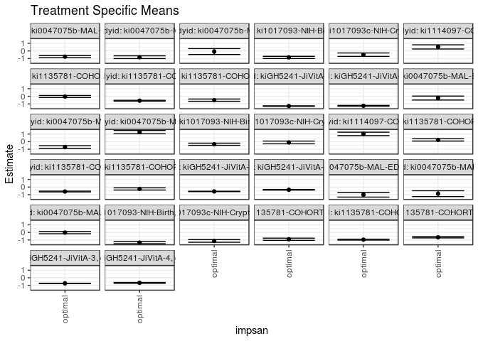

## Results Table

### Parameter: TSM

| agecat | studyid | country | intervention_level | baseline_level | estimate | ci_lower | ci_upper |
| --- | --- | --- | --- | --- | --- | --- | --- |
| Birth | ki0047075b-MAL-ED | BANGLADESH | optimal | observed | -1.0116290 | -1.3213763 | -0.7018817 |
| Birth | ki0047075b-MAL-ED | INDIA | optimal | observed | -0.8708215 | -1.2542413 | -0.4874017 |
| Birth | ki0047075b-MAL-ED | PERU | optimal | observed | -0.0236622 | -0.1752352 | 0.1279108 |
| Birth | ki1017093-NIH-Birth | BANGLADESH | optimal | observed | -1.3416422 | -1.4826303 | -1.2006540 |
| Birth | ki1017093c-NIH-Crypto | BANGLADESH | optimal | observed | -1.1204351 | -1.2945087 | -0.9463614 |
| Birth | ki1135781-COHORTS | GUATEMALA | optimal | observed | -0.8986885 | -1.0419898 | -0.7553873 |
| Birth | ki1135781-COHORTS | INDIA | optimal | observed | -0.9500680 | -1.0124720 | -0.8876640 |
| Birth | ki1135781-COHORTS | PHILIPPINES | optimal | observed | -0.6453054 | -0.7252629 | -0.5653479 |
| Birth | kiGH5241-JiVitA-3 | BANGLADESH | optimal | observed | -0.7321454 | -0.7530056 | -0.7112852 |
| Birth | kiGH5241-JiVitA-4 | BANGLADESH | optimal | observed | -0.6705718 | -0.7298691 | -0.6112745 |
| 6 months | ki0047075b-MAL-ED | BANGLADESH | optimal | observed | -0.2294804 | -0.4891309 | 0.0301701 |
| 6 months | ki0047075b-MAL-ED | INDIA | optimal | observed | -0.7026575 | -0.8818315 | -0.5234835 |
| 6 months | ki0047075b-MAL-ED | PERU | optimal | observed | 1.2565595 | 1.0373857 | 1.4757334 |
| 6 months | ki1017093-NIH-Birth | BANGLADESH | optimal | observed | -0.3390743 | -0.4803665 | -0.1977821 |
| 6 months | ki1017093c-NIH-Crypto | BANGLADESH | optimal | observed | -0.1005139 | -0.2797302 | 0.0787024 |
| 6 months | ki1114097-CONTENT | PERU | optimal | observed | 1.0190986 | 0.7916963 | 1.2465008 |
| 6 months | ki1135781-COHORTS | GUATEMALA | optimal | observed | 0.2327768 | 0.0821991 | 0.3833546 |
| 6 months | ki1135781-COHORTS | INDIA | optimal | observed | -0.5904176 | -0.6451754 | -0.5356599 |
| 6 months | ki1135781-COHORTS | PHILIPPINES | optimal | observed | -0.2492330 | -0.3937057 | -0.1047603 |
| 6 months | kiGH5241-JiVitA-3 | BANGLADESH | optimal | observed | -0.5784492 | -0.6043224 | -0.5525761 |
| 6 months | kiGH5241-JiVitA-4 | BANGLADESH | optimal | observed | -0.3567850 | -0.3988069 | -0.3147630 |
| 24 months | ki0047075b-MAL-ED | BANGLADESH | optimal | observed | -0.7497719 | -0.8823246 | -0.6172193 |
| 24 months | ki0047075b-MAL-ED | INDIA | optimal | observed | -0.8227791 | -1.0034251 | -0.6421331 |
| 24 months | ki0047075b-MAL-ED | PERU | optimal | observed | -0.0819454 | -0.4703684 | 0.3064776 |
| 24 months | ki1017093-NIH-Birth | BANGLADESH | optimal | observed | -0.8517562 | -0.9963715 | -0.7071410 |
| 24 months | ki1017093c-NIH-Crypto | BANGLADESH | optimal | observed | -0.4922499 | -0.7164919 | -0.2680079 |
| 24 months | ki1114097-CONTENT | PERU | optimal | observed | 0.5297661 | 0.2564854 | 0.8030468 |
| 24 months | ki1135781-COHORTS | GUATEMALA | optimal | observed | -0.0321012 | -0.1689590 | 0.1047566 |
| 24 months | ki1135781-COHORTS | INDIA | optimal | observed | -0.5762646 | -0.6298912 | -0.5226380 |
| 24 months | ki1135781-COHORTS | PHILIPPINES | optimal | observed | -0.5098430 | -0.6609528 | -0.3587331 |
| 24 months | kiGH5241-JiVitA-3 | BANGLADESH | optimal | observed | -1.2804607 | -1.3098197 | -1.2511018 |
| 24 months | kiGH5241-JiVitA-4 | BANGLADESH | optimal | observed | -1.2466627 | -1.2941165 | -1.1992088 |

### Parameter: E(Y)

| agecat | studyid | country | intervention_level | baseline_level | estimate | ci_lower | ci_upper |
| --- | --- | --- | --- | --- | --- | --- | --- |
| Birth | ki0047075b-MAL-ED | BANGLADESH | observed | observed | -0.9721393 | -1.1211171 | -0.8231615 |
| Birth | ki0047075b-MAL-ED | INDIA | observed | observed | -0.9441026 | -1.2397919 | -0.6484132 |
| Birth | ki0047075b-MAL-ED | PERU | observed | observed | -0.0381281 | -0.1669868 | 0.0907307 |
| Birth | ki1017093-NIH-Birth | BANGLADESH | observed | observed | -1.3499217 | -1.4444634 | -1.2553801 |
| Birth | ki1017093c-NIH-Crypto | BANGLADESH | observed | observed | -1.2402802 | -1.3249395 | -1.1556208 |
| Birth | ki1135781-COHORTS | GUATEMALA | observed | observed | -0.9294432 | -1.0701697 | -0.7887168 |
| Birth | ki1135781-COHORTS | INDIA | observed | observed | -0.9771733 | -1.0119896 | -0.9423570 |
| Birth | ki1135781-COHORTS | PHILIPPINES | observed | observed | -0.6841030 | -0.7582767 | -0.6099293 |
| Birth | kiGH5241-JiVitA-3 | BANGLADESH | observed | observed | -0.7501016 | -0.7679528 | -0.7322503 |
| Birth | kiGH5241-JiVitA-4 | BANGLADESH | observed | observed | -0.6882498 | -0.7406539 | -0.6358456 |
| 6 months | ki0047075b-MAL-ED | BANGLADESH | observed | observed | -0.1340556 | -0.2631866 | -0.0049245 |
| 6 months | ki0047075b-MAL-ED | INDIA | observed | observed | -0.7020815 | -0.8292964 | -0.5748666 |
| 6 months | ki0047075b-MAL-ED | PERU | observed | observed | 1.0402218 | 0.9168903 | 1.1635533 |
| 6 months | ki1017093-NIH-Birth | BANGLADESH | observed | observed | -0.4474038 | -0.5378167 | -0.3569909 |
| 6 months | ki1017093c-NIH-Crypto | BANGLADESH | observed | observed | 0.0336790 | -0.0458848 | 0.1132428 |
| 6 months | ki1114097-CONTENT | PERU | observed | observed | 1.0684318 | 0.9515274 | 1.1853362 |
| 6 months | ki1135781-COHORTS | GUATEMALA | observed | observed | 0.1458511 | 0.0589571 | 0.2327450 |
| 6 months | ki1135781-COHORTS | INDIA | observed | observed | -0.7104855 | -0.7428053 | -0.6781657 |
| 6 months | ki1135781-COHORTS | PHILIPPINES | observed | observed | -0.2830286 | -0.3471028 | -0.2189545 |
| 6 months | kiGH5241-JiVitA-3 | BANGLADESH | observed | observed | -0.5926506 | -0.6122450 | -0.5730562 |
| 6 months | kiGH5241-JiVitA-4 | BANGLADESH | observed | observed | -0.3901595 | -0.4274150 | -0.3529041 |
| 24 months | ki0047075b-MAL-ED | BANGLADESH | observed | observed | -0.8201887 | -0.9423967 | -0.6979806 |
| 24 months | ki0047075b-MAL-ED | INDIA | observed | observed | -0.9496667 | -1.0657716 | -0.8335618 |
| 24 months | ki0047075b-MAL-ED | PERU | observed | observed | 0.1069898 | -0.0141601 | 0.2281397 |
| 24 months | ki1017093-NIH-Birth | BANGLADESH | observed | observed | -0.9115790 | -1.0095022 | -0.8136559 |
| 24 months | ki1017093c-NIH-Crypto | BANGLADESH | observed | observed | -0.6115706 | -0.7075788 | -0.5155624 |
| 24 months | ki1114097-CONTENT | PERU | observed | observed | 0.5668293 | 0.4302437 | 0.7034148 |
| 24 months | ki1135781-COHORTS | GUATEMALA | observed | observed | -0.2861905 | -0.3461594 | -0.2262216 |
| 24 months | ki1135781-COHORTS | INDIA | observed | observed | -0.6606874 | -0.6938402 | -0.6275347 |
| 24 months | ki1135781-COHORTS | PHILIPPINES | observed | observed | -0.6564149 | -0.7144543 | -0.5983756 |
| 24 months | kiGH5241-JiVitA-3 | BANGLADESH | observed | observed | -1.2986562 | -1.3220237 | -1.2752887 |
| 24 months | kiGH5241-JiVitA-4 | BANGLADESH | observed | observed | -1.2231776 | -1.2550332 | -1.1913220 |

### Parameter: PAR

| agecat | studyid | country | intervention_level | baseline_level | estimate | ci_lower | ci_upper |
| --- | --- | --- | --- | --- | --- | --- | --- |
| Birth | ki0047075b-MAL-ED | BANGLADESH | optimal | observed | 0.0394897 | -0.2299056 | 0.3088850 |
| Birth | ki0047075b-MAL-ED | INDIA | optimal | observed | -0.0732811 | -0.3077297 | 0.1611676 |
| Birth | ki0047075b-MAL-ED | PERU | optimal | observed | -0.0144658 | -0.0944720 | 0.0655404 |
| Birth | ki1017093-NIH-Birth | BANGLADESH | optimal | observed | -0.0082796 | -0.1095677 | 0.0930086 |
| Birth | ki1017093c-NIH-Crypto | BANGLADESH | optimal | observed | -0.1198451 | -0.2702120 | 0.0305217 |
| Birth | ki1135781-COHORTS | GUATEMALA | optimal | observed | -0.0307547 | -0.0865778 | 0.0250685 |
| Birth | ki1135781-COHORTS | INDIA | optimal | observed | -0.0271053 | -0.0772781 | 0.0230675 |
| Birth | ki1135781-COHORTS | PHILIPPINES | optimal | observed | -0.0387976 | -0.0719710 | -0.0056242 |
| Birth | kiGH5241-JiVitA-3 | BANGLADESH | optimal | observed | -0.0179562 | -0.0281917 | -0.0077206 |
| Birth | kiGH5241-JiVitA-4 | BANGLADESH | optimal | observed | -0.0176780 | -0.0434899 | 0.0081340 |
| 6 months | ki0047075b-MAL-ED | BANGLADESH | optimal | observed | 0.0954248 | -0.1365688 | 0.3274185 |
| 6 months | ki0047075b-MAL-ED | INDIA | optimal | observed | 0.0005760 | -0.1342979 | 0.1354498 |
| 6 months | ki0047075b-MAL-ED | PERU | optimal | observed | -0.2163377 | -0.4075658 | -0.0251097 |
| 6 months | ki1017093-NIH-Birth | BANGLADESH | optimal | observed | -0.1083295 | -0.2227194 | 0.0060605 |
| 6 months | ki1017093c-NIH-Crypto | BANGLADESH | optimal | observed | 0.1341929 | -0.0175005 | 0.2858863 |
| 6 months | ki1114097-CONTENT | PERU | optimal | observed | 0.0493332 | -0.1352056 | 0.2338721 |
| 6 months | ki1135781-COHORTS | GUATEMALA | optimal | observed | -0.0869258 | -0.2207656 | 0.0469140 |
| 6 months | ki1135781-COHORTS | INDIA | optimal | observed | -0.1200679 | -0.1655562 | -0.0745796 |
| 6 months | ki1135781-COHORTS | PHILIPPINES | optimal | observed | -0.0337956 | -0.1661184 | 0.0985272 |
| 6 months | kiGH5241-JiVitA-3 | BANGLADESH | optimal | observed | -0.0142014 | -0.0302589 | 0.0018561 |
| 6 months | kiGH5241-JiVitA-4 | BANGLADESH | optimal | observed | -0.0333746 | -0.0535906 | -0.0131586 |
| 24 months | ki0047075b-MAL-ED | BANGLADESH | optimal | observed | -0.0704168 | -0.1254579 | -0.0153756 |
| 24 months | ki0047075b-MAL-ED | INDIA | optimal | observed | -0.1268876 | -0.2539710 | 0.0001959 |
| 24 months | ki0047075b-MAL-ED | PERU | optimal | observed | 0.1889352 | -0.1661032 | 0.5439736 |
| 24 months | ki1017093-NIH-Birth | BANGLADESH | optimal | observed | -0.0598228 | -0.1755263 | 0.0558806 |
| 24 months | ki1017093c-NIH-Crypto | BANGLADESH | optimal | observed | -0.1193207 | -0.3256260 | 0.0869847 |
| 24 months | ki1114097-CONTENT | PERU | optimal | observed | 0.0370632 | -0.2394604 | 0.3135867 |
| 24 months | ki1135781-COHORTS | GUATEMALA | optimal | observed | -0.2540893 | -0.3855377 | -0.1226409 |
| 24 months | ki1135781-COHORTS | INDIA | optimal | observed | -0.0844228 | -0.1268526 | -0.0419930 |
| 24 months | ki1135781-COHORTS | PHILIPPINES | optimal | observed | -0.1465719 | -0.2885784 | -0.0045655 |
| 24 months | kiGH5241-JiVitA-3 | BANGLADESH | optimal | observed | -0.0181954 | -0.0353035 | -0.0010874 |
| 24 months | kiGH5241-JiVitA-4 | BANGLADESH | optimal | observed | 0.0234851 | -0.0129011 | 0.0598713 |